# 1 Comparison of states on outcomes from storms and other severe weather events

## 1.1 Synopsis

[Storm Database](https://d396qusza40orc.cloudfront.net/repdata%2Fdata%2FStormData.csv.bz2) is an official publication of the National Oceanic and Atmospheric Administration (NOAA) which documents the occurrence of storms and other significant weather phenomena having sufficient intensity to cause loss of life, injuries, significant property damage, and/or disruption to commerce. In addition, it is a partial record of other significant meteorological events, such as record maximum or minimum temperatures or precipitation that occurs in connection with another event. Some information appearing in Storm Data may be provided by or gathered from sources outside the National Weather Service (NWS), such as the media, law enforcement and/or other government agencies, private companies, individuals, etc. An effort is made to use the best available information but because of time and resource constraints, information from these sources may be unverified by the NWS. Therefore, when using information from Storm Data, customers should be cautious as the NWS does not guarantee the accuracy or validity of the information. Further, when it is apparent information appearing in Storm Data originated from a source outside the NWS (frequently credit is provided), Storm Data customers requiring additional information should contact that source directly. In most cases, NWS employees will not have the knowledge to respond to such requests. In cases of legal cases, NWS employees will not have the knowledge to respond to such requests. In cases of legal proceedings, Federal regulations generally prohibit NWS employees from appearing as witnesses in litigation not involving the United States.

## 1.2 Data Processing

Please install “data.table”, “ggplot2” and “xtable” if you didn’t install them, then load these packages using the following commands.

```r
library(data.table)
library(ggplot2)
library(xtable)
```

Fix URL reading for knitr. See [Stackoverflow](http://stackoverflow.com/a/20003380).

```r
setInternet2(TRUE)
```

### 1.2.1 Download and unzip files

Download the storm data documentation files.

- National Weather Service [Storm Data Documentation](https://d396qusza40orc.cloudfront.net/repdata%2Fpeer2_doc%2Fpd01016005curr.pdf)
- National Climatic Data Center Storm Events [FAQ](https://d396qusza40orc.cloudfront.net/repdata%2Fpeer2_doc%2FNCDC%20Storm%20Events-FAQ%20Page.pdf)

```r
url <- "https://d396qusza40orc.cloudfront.net/repdata%2Fpeer2_doc%2Fpd01016005curr.pdf"
f <- file.path(getwd(), "StormDataDocumentation.pdf")
download.file(url, f, mode="wb")
url <- "https://d396qusza40orc.cloudfront.net/repdata%2Fpeer2_doc%2FNCDC%20Storm%20Events-FAQ%20Page.pdf"
f <- file.path(getwd(), "StormEventsFAQ.pdf")
download.file(url, f, mode="wb")
```

Download the zipped [storm data file](https://d396qusza40orc.cloudfront.net/repdata%2Fdata%2FStormData.csv.bz2).

```r
url <- "https://d396qusza40orc.cloudfront.net/repdata%2Fdata%2FStormData.csv.bz2"
f <- file.path(getwd(), "repdata_data_StormData.csv.bz2")
download.file(url, f, mode="wb")
```

Unzip the data file: The bz2 zip file should be unzipped using 7z software. If you don’t have this software installed, please download it at website http://www.7-zip.org/ and install it.

```r
executable <- file.path("C:", "Program Files", "7-Zip", "7z.exe")
parameters <- "x"
switch <- "-aoa"
cmd <- paste(paste0("\"", executable, "\""), parameters, paste0("\"", f, "\""), switch)
cmd
```

```
## [1] "\"C:/Program Files/7-Zip/7z.exe\" x \"D:/GitHub/nhatmn_course05_W03_Peer_Assessment2/repdata_data_StormData.csv.bz2\" -aoa"
```

```r
system(cmd)
```

### 1.2.2 Read data file

The data file (CSV format) is in the working directory. Read the CSV file as a data frame. Then convert to a data table.

```r
f <- file.path(getwd(), "repdata_data_StormData.csv")
D <- read.csv(f, stringsAsFactors=FALSE)
D <- data.table(D)
str(D)
```

```
## Classes 'data.table' and 'data.frame':   902297 obs. of  37 variables:
##  $ STATE__   : num  1 1 1 1 1 1 1 1 1 1 ...
##  $ BGN_DATE  : chr  "4/18/1950 0:00:00" "4/18/1950 0:00:00" "2/20/1951 0:00:00" "6/8/1951 0:00:00" ...
##  $ BGN_TIME  : chr  "0130" "0145" "1600" "0900" ...
##  $ TIME_ZONE : chr  "CST" "CST" "CST" "CST" ...
##  $ COUNTY    : num  97 3 57 89 43 77 9 123 125 57 ...
##  $ COUNTYNAME: chr  "MOBILE" "BALDWIN" "FAYETTE" "MADISON" ...
##  $ STATE     : chr  "AL" "AL" "AL" "AL" ...
##  $ EVTYPE    : chr  "TORNADO" "TORNADO" "TORNADO" "TORNADO" ...
##  $ BGN_RANGE : num  0 0 0 0 0 0 0 0 0 0 ...
##  $ BGN_AZI   : chr  "" "" "" "" ...
##  $ BGN_LOCATI: chr  "" "" "" "" ...
##  $ END_DATE  : chr  "" "" "" "" ...
##  $ END_TIME  : chr  "" "" "" "" ...
##  $ COUNTY_END: num  0 0 0 0 0 0 0 0 0 0 ...
```

[output cut: 24 more lines]

### 1.2.3 Clean data

Rename the variables to lowercase for ease of coding.

```r
old <- names(D)
new <- tolower(old)
setnames(D, old, new)
```

Convert the `bgn_date` character class variable to a date class variable.

```r
bgn_date <- strsplit(D$bgn_date, "[^[:digit:]]")
bgn_date <- unlist(bgn_date)
bgn_date <- as.numeric(bgn_date)
bgn_date <- matrix(bgn_date, nrow=nrow(D), byrow=TRUE)
dateStr <- sprintf("%4d%02d%02d", bgn_date[, 3], bgn_date[, 1], bgn_date[, 2])
D <- D[, beginDate := as.Date(dateStr, format="%Y%m%d")]
rm(bgn_date, dateStr)
```

Scale the property damage variable into a new variable, `propertyDamage`.

- If `propdmgexp` = `B`, then multiply `propdmg` by 1,000,000,000
- Else if `propdmgexp` = `M`, then multiply `propdmg` by 1,000,000
- Else if `propdmgexp` = `K`, then multiply `propdmg` by 1,000
- Else if `propdmgexp` = `H`, then multiply `propdmg` by 100
- Else leave `propdmg` as-is

```r
D <- D[, propdmgexp := toupper(propdmgexp)]
D[, .N, propdmgexp]
```

```
##     propdmgexp      N
##  1:          K 424665
##  2:          M  11337
##  3:            465934
##  4:          B     40
##  5:          +      5
##  6:          0    216
##  7:          5     28
##  8:          6      4
##  9:          ?      8
## 10:          4      4
## 11:          2     13
## 12:          3      4
## 13:          H      7
## 14:          7      5
## 15:          -      1
## 16:          1     25
## 17:          8      1
```

```r
D <- D[, propertyDamage := ifelse(propdmgexp == "B", propdmg * 1E9, ifelse(propdmgexp == "M", propdmg * 1E6, ifelse(propdmgexp == "K", propdmg * 1E3, ifelse(propdmgexp == "H", propdmg * 1E2, propdmg))))]
summary(D$propertyDamage)
```

```
##      Min.   1st Qu.    Median      Mean   3rd Qu.      Max.
## 0.000e+00 0.000e+00 0.000e+00 4.736e+05 5.000e+02 1.150e+11
```

Scale the crop damage variable into a new variable, `cropDamage`.

- If `cropdmgexp` = `B`, then multiply `cropdmg` by 1,000,000,000
- Else if `cropdmgexp` = `M`, then multiply `cropdmg` by 1,000,000
- Else if `cropdmgexp` = `K`, then multiply `cropdmg` by 1,000
- Else leave `cropdmg` as-is

```r
D <- D[, cropdmgexp := toupper(cropdmgexp)]
D[, .N, cropdmgexp]
```

```
##    cropdmgexp      N
## 1:            618413
## 2:          M   1995
## 3:          K 281853
## 4:          B      9
## 5:          ?      7
## 6:          0     19
## 7:          2      1
```

```r
D <- D[, cropDamage := ifelse(cropdmgexp == "B", cropdmg * 1E9, ifelse(cropdmgexp == "M", cropdmg * 1E6, ifelse(cropdmgexp == "K", cropdmg * 1E3, cropdmg)))]
summary(D$cropDamage)
```

```
##      Min.   1st Qu.    Median      Mean   3rd Qu.      Max.
## 0.000e+00 0.000e+00 0.000e+00 5.442e+04 0.000e+00 5.000e+09
```

#### 1.2.3.1 Group event types

List the number of unique values of `evtype`. The number of unique values is too large to manage without some grouping.

```r
message(sprintf("Number of unique values of evtype: %.0d", length(unique(D$evtype))))
```

```
## Number of unique values of evtype: 985
```

Group event types to mimic the categories found in the [2009 Annual Summaries](http://www.ncdc.noaa.gov/oa/climate/sd/annsum2009.pdf) on page 3.

`evtype` needs a lot of data cleaning. Particularly, values need to be grouped to resolve spelling variations. Also, records can have multiple events listed in the `evtype` variable. Create indicator variables for common event types.

```r
indicator <- function (regex) {
    indicator <- grepl(regex, D$evtype, ignore.case=TRUE)
    uniqueEventTypes <- unique(D[indicator, evtype])
    show(uniqueEventTypes[order(uniqueEventTypes)])
    indicator
}
```

Create an indicators for variations of **Lightning**, **Tornado**, **Thunderstorm Wind**, and **Hail**. List the event types that fall into the category of **Convection**.

```r
regexLightning <- "\\bL\\S+?G\\b"
regexTornado <- "(NADO)|(\\bTOR\\S+?O\\b|(\\bFUN))"
regexThunderstorm <- "THUNDERSTORM|TSTM"
regexWind <- "(WIND)|(WND)"
regexHail <- "HAIL"
regex <- paste(regexLightning, regexTornado, regexThunderstorm, regexWind, regexHail, sep="|")
D <- D[, eventConvection := indicator(regex)]
```

```
##   [1] " LIGHTNING"                     " TSTM WIND"
##   [3] " TSTM WIND (G45)"               " WIND"
##   [5] "BITTER WIND CHILL"              "BITTER WIND CHILL TEMPERATURES"
##   [7] "BLIZZARD AND EXTREME WIND CHIL" "BLIZZARD/HIGH WIND"
##   [9] "BLOWING SNOW- EXTREME WIND CHI" "BLOWING SNOW & EXTREME WIND CH"
##  [11] "BLOWING SNOW/EXTREME WIND CHIL" "COLD AIR FUNNEL"
##  [13] "COLD AIR FUNNELS"               "COLD AIR TORNADO"
##  [15] "COLD WIND CHILL TEMPERATURES"   "COLD/WIND CHILL"
##  [17] "COLD/WINDS"                     "DEEP HAIL"
##  [19] "DOWNBURST WINDS"                "DRY MICROBURST WINDS"
##  [21] "DRY MIRCOBURST WINDS"           "DUST STORM/HIGH WINDS"
##  [23] "EXTREME COLD/WIND CHILL"        "EXTREME WIND CHILL"
##  [25] "EXTREME WIND CHILL/BLOWING SNO" "EXTREME WIND CHILLS"
##  [27] "EXTREME WINDCHILL"              "EXTREME WINDCHILL TEMPERATURES"
##  [29] "FLASH FLOOD WINDS"              "FLASH FLOODING/THUNDERSTORM WI"
```

[output cut: 148 more lines]

Create an indicators for variations of **Cold** and **Heat**. List the event types that fall into the category of **Extreme Temperatures**.

```r
regex <- "COLD|HEAT"
D <- D[, eventExtremeTemp := indicator(regex)]
```

```
##  [1] "Cold"                         "COLD"
##  [3] "COLD AIR FUNNEL"              "COLD AIR FUNNELS"
##  [5] "COLD AIR TORNADO"             "Cold and Frost"
##  [7] "COLD AND FROST"               "COLD AND SNOW"
##  [9] "COLD AND WET CONDITIONS"      "Cold Temperature"
## [11] "COLD TEMPERATURES"            "COLD WAVE"
## [13] "COLD WEATHER"                 "COLD WIND CHILL TEMPERATURES"
## [15] "COLD/WIND CHILL"              "COLD/WINDS"
## [17] "DROUGHT/EXCESSIVE HEAT"       "Excessive Cold"
## [19] "EXCESSIVE HEAT"               "EXCESSIVE HEAT/DROUGHT"
## [21] "Extended Cold"                "Extreme Cold"
## [23] "EXTREME COLD"                 "EXTREME COLD/WIND CHILL"
## [25] "EXTREME HEAT"                 "EXTREME/RECORD COLD"
## [27] "FOG AND COLD TEMPERATURES"    "HEAT"
## [29] "HEAT DROUGHT"                 "Heat Wave"
## [31] "HEAT WAVE"                    "HEAT WAVE DROUGHT"
## [33] "HEAT WAVES"                   "HEAT/DROUGHT"
## [35] "Heatburst"                    "HIGH WINDS/COLD"
## [37] "Prolong Cold"                 "PROLONG COLD"
## [39] "PROLONG COLD/SNOW"            "RECORD  COLD"
## [41] "Record Cold"                  "RECORD COLD"
## [43] "RECORD COLD AND HIGH WIND"    "RECORD COLD/FROST"
## [45] "Record Heat"                  "RECORD HEAT"
## [47] "RECORD HEAT WAVE"             "RECORD SNOW/COLD"
## [49] "RECORD/EXCESSIVE HEAT"        "SEVERE COLD"
## [51] "SNOW AND COLD"                "SNOW/ BITTER COLD"
## [53] "SNOW/COLD"                    "SNOW\\COLD"
## [55] "Unseasonable Cold"            "UNSEASONABLY COLD"
## [57] "UNUSUALLY COLD"
```

Create an indicators for variations of **Flood** and **Rain**. List the event types that fall into the category of **Flood**.

```r
regexFlood <- "(\\bFL\\S+?D)"
regexRain <- "RAIN|PRECIP|SHOWER"
regex <- paste(regexFlood, regexRain, sep="|")
D <- D[, eventFlood := indicator(regex)]
```

```
##   [1] " COASTAL FLOOD"                 " FLASH FLOOD"
##   [3] "BEACH EROSION/COASTAL FLOOD"    "BEACH FLOOD"
##   [5] "BELOW NORMAL PRECIPITATION"     "BLIZZARD/FREEZING RAIN"
##   [7] "BREAKUP FLOODING"               "COASTAL  FLOODING/EROSION"
##   [9] "Coastal Flood"                  "COASTAL FLOOD"
##  [11] "coastal flooding"               "Coastal Flooding"
##  [13] "COASTAL FLOODING"               "COASTAL FLOODING/EROSION"
##  [15] "COASTAL/TIDAL FLOOD"            "CSTL FLOODING/EROSION"
##  [17] "EARLY RAIN"                     "Erosion/Cstl Flood"
##  [19] "EXCESSIVE PRECIPITATION"        "EXCESSIVE RAIN"
##  [21] "EXCESSIVE RAINFALL"             "FLASH FLOOD"
##  [23] "FLASH FLOOD - HEAVY RAIN"       "FLASH FLOOD FROM ICE JAMS"
##  [25] "FLASH FLOOD LANDSLIDES"         "FLASH FLOOD WINDS"
##  [27] "FLASH FLOOD/"                   "FLASH FLOOD/ FLOOD"
##  [29] "FLASH FLOOD/ STREET"            "FLASH FLOOD/FLOOD"
```

[output cut: 83 more lines]

Create an indicator for variations of **Snow**, **Ice**, **Freeze**, or **Winter Weather**. List the event types that fall into the category of **Winter**.

```r
regex <- "(SNOW)|(ICE)|(ICY)|(FREEZ)|(WINT)"
D <- D[, eventWinter := indicator(regex)]
```

```
##   [1] "ACCUMULATED SNOWFALL"           "AGRICULTURAL FREEZE"
##   [3] "Black Ice"                      "BLACK ICE"
##   [5] "BLIZZARD AND HEAVY SNOW"        "BLIZZARD/FREEZING RAIN"
##   [7] "BLIZZARD/HEAVY SNOW"            "BLIZZARD/WINTER STORM"
##   [9] "blowing snow"                   "Blowing Snow"
##  [11] "BLOWING SNOW"                   "BLOWING SNOW- EXTREME WIND CHI"
##  [13] "BLOWING SNOW & EXTREME WIND CH" "BLOWING SNOW/EXTREME WIND CHIL"
##  [15] "COLD AND SNOW"                  "Damaging Freeze"
##  [17] "DAMAGING FREEZE"                "Drifting Snow"
##  [19] "EARLY FREEZE"                   "EARLY SNOW"
##  [21] "Early snowfall"                 "EARLY SNOWFALL"
##  [23] "EXCESSIVE SNOW"                 "FALLING SNOW/ICE"
##  [25] "FIRST SNOW"                     "FLASH FLOOD FROM ICE JAMS"
##  [27] "Freeze"                         "FREEZE"
##  [29] "Freezing drizzle"               "Freezing Drizzle"
```

[output cut: 85 more lines]

Calculate the proportion of records that don’t satisfy any one of the defined indicators. Calculate the number of unique event types among these records. List the ungrouped unique event types.

```r
where <- expression(eventConvection == FALSE & eventExtremeTemp == FALSE & eventFlood == FALSE & eventWinter == FALSE)
ungrouped <- D[eval(where), list(n = .N, prop = .N / nrow(D))]
prop <- D[eval(where), .N / nrow(D)]
message(sprintf("Number (%%) of records that don't satisfy any one of the defined indicators: %.0d (%.2f%%)", ungrouped$n, ungrouped$prop * 100))
```

```
## Number (%) of records that don't satisfy any one of the defined indicators: 25040 (2.78%)
```

```r
uniqueEvtype <- unique(D[eval(where), evtype])
message(sprintf("Number of unique event types that don't satisfy any one of the defined indicators: %.0d", length(uniqueEvtype)))
```

```
## Number of unique event types that don't satisfy any one of the defined indicators: 306
```

```r
uniqueEvtype[order(uniqueEvtype)]
```

```
##   [1] "   HIGH SURF ADVISORY"      " WATERSPOUT"
##   [3] "?"                          "ABNORMAL WARMTH"
##   [5] "ABNORMALLY DRY"             "ABNORMALLY WET"
##   [7] "APACHE COUNTY"              "ASTRONOMICAL HIGH TIDE"
##   [9] "ASTRONOMICAL LOW TIDE"      "AVALANCE"
##  [11] "AVALANCHE"                  "BEACH EROSIN"
##  [13] "Beach Erosion"              "BEACH EROSION"
##  [15] "BLIZZARD"                   "Blizzard Summary"
##  [17] "BLIZZARD WEATHER"           "BLOW-OUT TIDE"
##  [19] "BLOW-OUT TIDES"             "BLOWING DUST"
##  [21] "BRUSH FIRE"                 "BRUSH FIRES"
##  [23] "COASTAL EROSION"            "Coastal Storm"
##  [25] "COASTAL STORM"              "COASTAL SURGE"
##  [27] "COASTALFLOOD"               "COASTALSTORM"
##  [29] "COOL AND WET"               "COOL SPELL"
```

[output cut: 138 more lines]

Create an **Other** indicator for ungrouped event types.

```r
D <- D[, eventOther := eventConvection == FALSE & eventExtremeTemp == FALSE & eventFlood == FALSE & eventWinter == FALSE]
```

A crosstabulation for the event type categories is below.

```r
groupby <- expression(list(eventConvection, eventExtremeTemp, eventFlood, eventWinter, eventOther))
D[, .N, eval(groupby)][order(eventConvection, eventExtremeTemp, eventFlood, eventWinter, eventOther, decreasing=TRUE)]
```

```
##     eventConvection eventExtremeTemp eventFlood eventWinter eventOther
##  1:            TRUE             TRUE      FALSE       FALSE      FALSE
##  2:            TRUE            FALSE       TRUE        TRUE      FALSE
##  3:            TRUE            FALSE       TRUE       FALSE      FALSE
##  4:            TRUE            FALSE      FALSE        TRUE      FALSE
##  5:            TRUE            FALSE      FALSE       FALSE      FALSE
##  6:           FALSE             TRUE      FALSE        TRUE      FALSE
##  7:           FALSE             TRUE      FALSE       FALSE      FALSE
##  8:           FALSE            FALSE       TRUE        TRUE      FALSE
##  9:           FALSE            FALSE       TRUE       FALSE      FALSE
## 10:           FALSE            FALSE      FALSE        TRUE      FALSE
## 11:           FALSE            FALSE      FALSE       FALSE       TRUE
##          N
##  1:   1561
##  2:      1
##  3:     41
##  4:     28
##  5: 736109
##  6:      9
##  7:   3541
##  8:    371
##  9:  94639
## 10:  40957
## 11:  25040
```

#### 1.2.3.2 Categorize event types

Now that event types are grouped, set up a categorization hierarchy of event types. The hierarchy is needed because records can have multiple events listed in the `evtype` variable. E.g., *THUNDERSTORM WINDS/FLASH FLOOD*.

The hierarchy is as follows.

1. Convection (including lightning, tornado, thunderstorm, wind, and hail)
2. Extreme temperature (including hot and cold)
3. Flood (including flood, flash flood, rain)
4. Winter (including snow, ice, freeze, or winter weather)
5. Other

Under this categorization hierarchy, the example event type of *THUNDERSTORM WINDS/FLASH FLOOD* would be assigned to the *Convection* category. I.e., higher categories outrank lower categories.

```r
D <- D[, eventCategory := ifelse(eventConvection, 1, ifelse(eventExtremeTemp, 2, ifelse(eventFlood, 3, ifelse(eventWinter, 4, ifelse(eventOther, 5, NA)))))]
labels <- c("Convection", "Extreme temperature", "Flood", "Winter", "Other")
D <- D[, eventCategory := factor(eventCategory, labels=labels)]
D[, .N, eventCategory]
```

```
##          eventCategory      N
## 1:          Convection 737740
## 2:               Flood  95010
## 3:              Winter  40957
## 4: Extreme temperature   3550
## 5:               Other  25040
```

### 1.2.4 Restrict date range

The date ranges for each category are below.

```r
select <- expression(list(numberEvents = .N, minDate = min(beginDate), maxDate = max(beginDate)))
groupby <- expression(list(eventCategory))
tabEventCategory <- D[, eval(select), eval(groupby)]
tabEventCategory <- tabEventCategory[order(eventCategory)]
message(sprintf("Convection events reach as far back as %.0d.", year(min(D$beginDate[D$eventCategory == "Convection"]))))
```

```
## Convection events reach as far back as 1950.
```

```r
message(sprintf("However, the other categories only reach as far back as %.0d.", year(min(D$beginDate[D$eventCategory != "Convection"]))))
```

```
## However, the other categories only reach as far back as 1993.
```

Filter the data to include records with dates between a range that includes all categories.

```r
minYear <- year(min(D$beginDate[D$eventCategory != "Convection"]))
maxYear <- year(max(D$beginDate))
D <- D[minYear <= year(beginDate) & year(beginDate) <= maxYear]
message(sprintf("For the purpose of this analysis, the date range will be limited to %.0d to %.0d.", minYear, maxYear))
```

```
## For the purpose of this analysis, the date range will be limited to 1993 to 2011.
```

### 1.2.5 Restrict to 50 states

Restrict the data to records from the 50 states. Use R’s built-in `state.abb` dataset.

```r
D <- D[state %in% state.abb]
```

### 1.2.6 Reshape data

Reshape data table with essential variables for tabulation and plotting.

```r
labels <- c("Convection", "Extreme temperature", "Flood", "Winter", "Other")
D2 <- rbind(D[, list(state, year = year(beginDate), eventCategory = factor(eventCategory, labels=labels), outcome = "Fatalities (thousands)", value = fatalities / 1E3)],
            D[, list(state, year = year(beginDate), eventCategory = factor(eventCategory, labels=labels), outcome = "Injuries (thousands)", value = injuries / 1E3)],
            D[, list(state, year = year(beginDate), eventCategory = factor(eventCategory, labels=labels), outcome = "Property damage ($, billions)", value = propertyDamage / 1E9)])
```

Tabulate by state and category, and by state. For the state tabulation, rank each state according to outcome.

```r
tabulationStateCategory <- D2[, list(value = sum(value)), list(state, eventCategory, outcome)]
tabulationState <- D2[, list(value = sum(value)), list(state, outcome)]
tabulationState <- tabulationState[, rank := abs(rank(value, ties.method="random") - 51), list(outcome)]
```

## 1.3 Results

Plot each state as a [coxcomb](http://understandinguncertainty.org/coxcombs), or rose. Each rose shows the magnitude of each outcome * **F**atalities, at the 2 o’clock position * **I**njuries, at the 6 o’clock position, and * **P**roperty damage, at the 10 o’clock position

The color of each bar segment corresponds to event category. The outcomes combine data from 1993 to 2011.

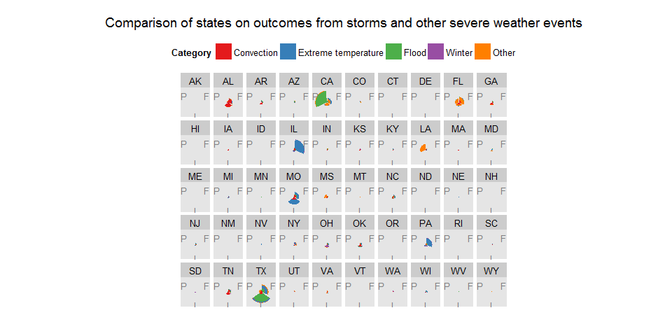

```r
tabulationStateCategory <- tabulationStateCategory[, valueScaled := scale(value, center=FALSE), list(outcome)]
ggplot(tabulationStateCategory, aes(x=outcome, y=valueScaled, fill=eventCategory)) +
  geom_bar(alpha=1, stat="identity") +
  coord_polar(theta="x") +
  scale_fill_brewer(name="Category", palette="Set1") +
  scale_x_discrete(name="", labels=c("F", "I", "P")) +
  scale_y_continuous(name="", labels=NULL) +
  facet_wrap(~ state, nrow=5, ncol=10) +
  labs(title="Comparison of states on outcomes from storms and other severe weather events") +
  theme(legend.position="top") +
  theme(axis.ticks.y=element_blank(),
        panel.grid=element_blank())
```

Tabulate the highest ranking state for each outcome.

**Fatalities**

```r
top <- tabulationState[grepl("Fatal", outcome) & rank <= 1, state]
where <- expression(state %in% top & grepl("Fatal", outcome))
select <- expression(list(state, value = format(value * 1E3, big.mark=","), eventCategory))
tabulation <- tabulationStateCategory[eval(where), eval(select)]
tabulation <- tabulation[order(value, decreasing=TRUE)]
print(xtable(tabulation, digits=0), type="html", include.rownames=FALSE)
```

| state | value | eventCategory |
| --- | --- | --- |
| IL | 998 | Extreme temperature |
| IL | 181 | Convection |
| IL | 24 | Flood |
| IL | 20 | Winter |
| IL | 4 | Other |

**Injuries**

```r
top <- tabulationState[grepl("Inj", outcome) & rank <= 1, state]
where <- expression(state %in% top & grepl("Inj", outcome))
select <- expression(list(state, value = format(value * 1E3, big.mark=","), eventCategory))
tabulation <- tabulationStateCategory[eval(where), eval(select)]
tabulation <- tabulation[order(value, decreasing=TRUE)]
print(xtable(tabulation, digits=0), type="html", include.rownames=FALSE)
```

| state | value | eventCategory |
| --- | --- | --- |
| TX | 6,951 | Flood |
| TX | 1,997 | Convection |
| TX | 787 | Extreme temperature |
| TX | 211 | Winter |
| TX | 186 | Other |

**Property damage**

```r
top <- tabulationState[grepl("Prop", outcome) & rank <= 1, state]
where <- expression(state %in% top & grepl("Prop", outcome))
select <- expression(list(state, value = sprintf("$%s billion", format(round(value, digits=1), big.mark=",")), eventCategory))
tabulation <- tabulationStateCategory[eval(where), eval(select)]
tabulation <- tabulation[order(value, decreasing=TRUE)]
print(xtable(tabulation, digits=0), type="html", include.rownames=FALSE)
```

| state | value | eventCategory |
| --- | --- | --- |
| CA | $117.4 billion | Flood |
| CA | $ 5.3 billion | Other |
| CA | $ 0.6 billion | Convection |
| CA | $ 0.1 billion | Winter |
| CA | $ 0.0 billion | Extreme temperature |

**From above result, we can have the answers for below questions:**

- Across the United States, which types of events (as indicated in the EVTYPE variable) are most harmful with respect to population health?
  - Please take a look at "Fatalities" and "Injuries" above.
- Across the United States, which types of events have the greatest economic consequences?
  - Please take a look at "Property damage" above.